# Images counts by kingdom, basisofrecord, and license

**basis of record** tells us roughly whether an image was collected in situ (human observation like with a phone) or was collected or digitized by a museum (preserved specimen).

Not many images are available for commercial use, but many images are still available for non-commercial use. Perhaps **iNaturalist** images are licensed as non-commercial, but will still be available?

Still there are thousands to millions of images available through the GBIF network.

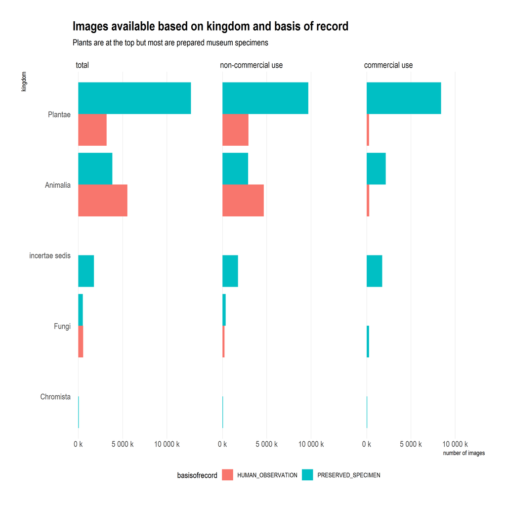

# Here we have images broken down by class, basisofrecord, and license

At a lower taxonomic level we see that **flowering plants (magnoliopsida)** have many images.

Also we notice that many groups have thousands of images.

Again **commercial use** might be difficult for many groups…

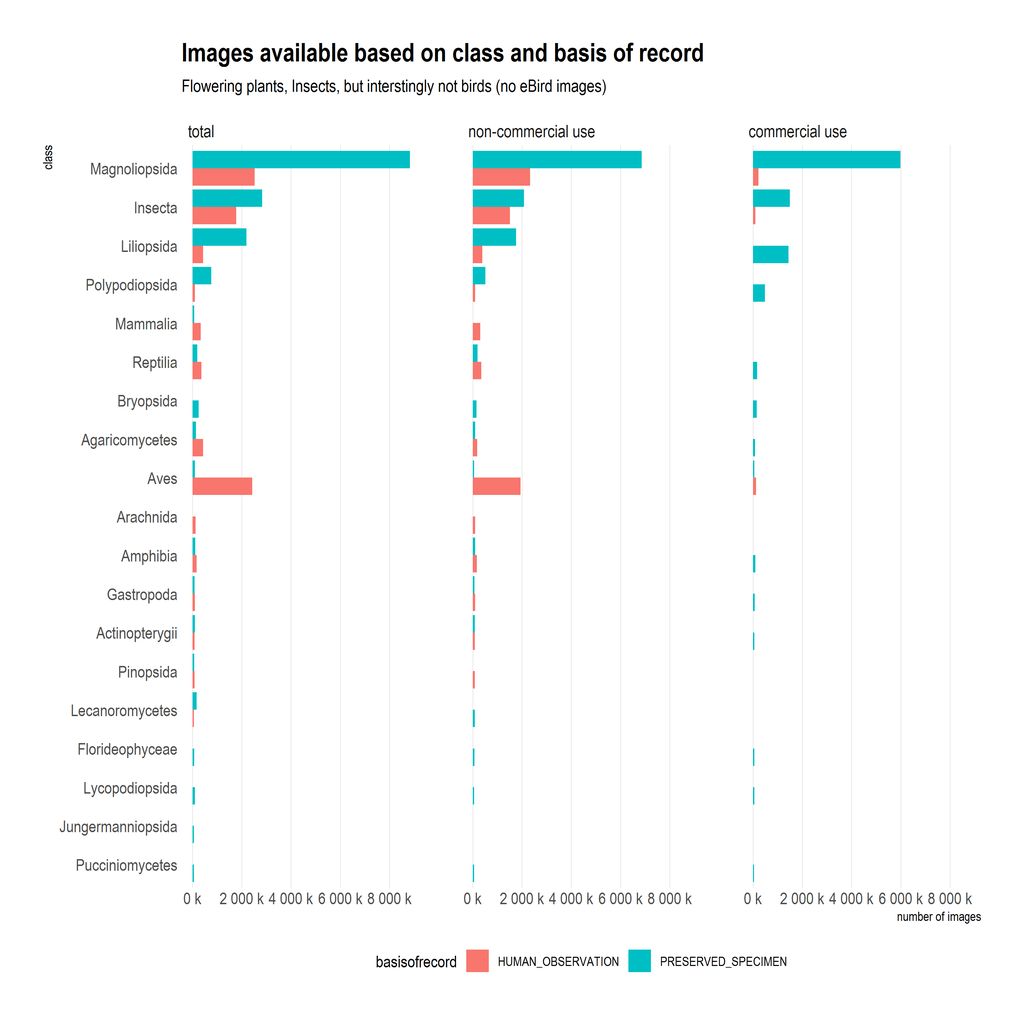

[figure not shown]

# Groups with a 1000s species with >10 images

Here are groups (based on taxonomic class), which have >1000 species with >10 images.

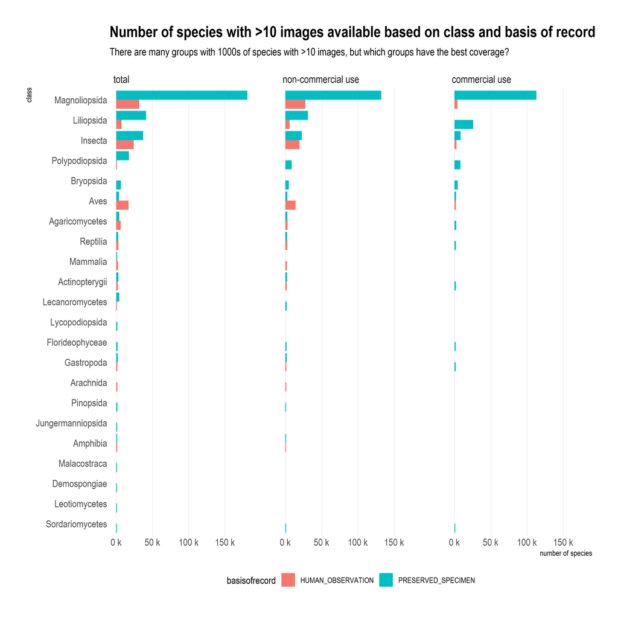

# Percent coverage of species with >10 images

**Percent coverage (num. sp. >10 img/total num. sp. in class)**. Here we see that global image coverage is quite poor for most groups with the exception of maybe **Aves** (birds) and a few plant classes (**Pinopsida**, **Lycopodiopsida**, **Polypodiopsida**), although many of these plant classes are “preserved specimens” aka probably herbarium sheets. Other groups have very poor global image coverage even considering preserved museum specimens.

The global look for images for commercial use is even worse, although there is reasonable non-commercial (open access) image coverage.

**Species counts** were taken from **GBIF backbone** and probably should be interpreted with caution. Duplicates might explain why we see >100% in some cases. A better measure might be the total number of species for which we have **at least 1 occurrence**. Still this graphs shows that **regional breakdowns** are probably necessary for an image dataset with good coverage.

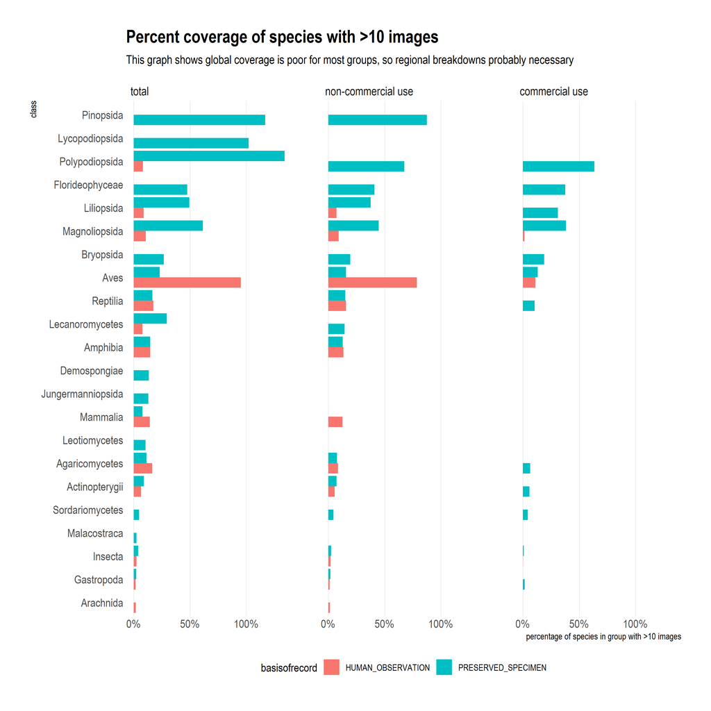

# Selected regional coverage